# CM3015 Machine Learning and Neural Networks - 2

## Table of Contents

The universal workflow of machine learning by François Chollet.

### Introduction

1. Defining the problem and assembling a dataset
2. Choosing a measure of success
3. Deciding on an evaluation protocol

### Implementation

1. Preparing the data
2. Developing a model that does better than a baseline
3. Scaling up: developing a model that overfits
4. Regularizing the model and tuning the hyperparameters

### Results

1. Presentation of results
2. Evaluation of results

# Introduction

## Defining the problem and assembling a dataset

[ Dataset ]  
[Breast Cancer Wisconsin (Diagnostic)](https://archive.ics.uci.edu/ml/machine-learning-databases/breast-cancer-wisconsin/)

[ Source ]  
[UCI Machine Learning Repository](https://archive.ics.uci.edu/ml/index.php)

[ Classification ]  
Binary classification  
M = malignant, B = benign

- Malignant tumors are cancerous and can grow rapidly, invade and destroy nearby tissues.
- Benign tumors are noncancerous and do not invade nearby tissue or spread to other parts of the body.

[ Attribute information ]  
Number of attribues: 32  
Field 1: ID Number  
Field 2: Diagnosis  
Fields 3 - 32: Ten real-valued features computed for each cell nucleus

The mean, standard error (SE), and the mean of the three largest values (Worst) of these features were computed for each image, resulting in 30 features. E.g. Field 3 is Mean Radius, field 13 is Radius SE, field 23 is Worst Radius.

Feature descriptions:

| Feature | Description |
| --- | --- |
| Feature 1 | Radius (mean of distances from center to points on the perimeter) |
| Feature 2 | Texture (standard deviation of gray-scale values) |
| Feature 3 | Perimeter |
| Feature 4 | Area |
| Feature 5 | Smoothness (local variation in radius lengths) |
| Feature 6 | Compactness (perimeter^2 / area - 1.0) |
| Feature 7 | Concavity (severity of concave portions of the contour) |
| Feature 8 | Concave points (number of concave portions of the contour) |
| Feature 9 | Symmetry |
| Feature 10 | Fractal dimension ("coastline approximation" - 1) |

## Choosing a measure of success

Input: 569 instances  
Output: M = malignant or B = benign  
Class distribution: 357 benign, 212 malignant

Recall will be used to measure the success of the model as the class distribution is imbalanced. It is a useful metric when the cost of a false negative prediction is high. In this case, where the positive class is malignant, we want to measure the proportion of correctly predicted malignant cases among all actual malignant cases.

## Deciding on an evaluation protocol

We will be using k-fold Cross-Validation as the dataset is relatively small.

# Implementation

## Preparing the data

The dataset does not contain any headers so we will add that in manually (refer to attribute information above)

```python
import numpy as np
import pandas as pd
import tensorflow as tf
import matplotlib.pyplot as plt
from keras import backend as K
from keras.layers import Dense
from keras.models import Sequential
from sklearn.preprocessing import LabelEncoder
from sklearn.preprocessing import StandardScaler
from sklearn.model_selection import train_test_split
from sklearn.metrics import confusion_matrix, ConfusionMatrixDisplay
```

```python
DATASET = "https://archive.ics.uci.edu/ml/machine-learning-databases/breast-cancer-wisconsin/wdbc.data"
HEADERS = ["ID Number", "Diagnosis", "Radius (mean)", "Texture (mean)", "Perimeter (mean)", "Area (mean)",
           "Smoothness (mean)", "Compactness (mean)", "Concavity (mean)", "Concave points (mean)", "Symmetry (mean)",
           "Fractal dimension (mean)", "Radius (SE)", "Texture (SE)", "Perimeter (SE)", "Area (SE)", "Smoothness (SE)",
           "Compactness (SE)", "Concavity (SE)", "Concave points (SE)", "Symmetry (SE)", "Fractal dimension (SE)",
           "Radius (worst)", "Texture (worst)", "Perimeter (worst)", "Area (worst)", "Smoothness (worst)",
           "Compactness (worst)", "Concavity (worst)", "Concave points", "Symmetry (worst)", "Fractal dimension (worst)"]
```

```python
df = pd.read_csv(DATASET, header=None)
df.columns = HEADERS
df.head()
```

|  | ID Number | Diagnosis | Radius (mean) | Texture (mean) | Perimeter (mean) | Area (mean) | Smoothness (mean) | Compactness (mean) | Concavity (mean) | Concave points (mean) | ... | Radius (worst) | Texture (worst) | Perimeter (worst) | Area (worst) | Smoothness (worst) | Compactness (worst) | Concavity (worst) | Concave points | Symmetry (worst) | Fractal dimension (worst) |
| --- | --- | --- | --- | --- | --- | --- | --- | --- | --- | --- | --- | --- | --- | --- | --- | --- | --- | --- | --- | --- | --- |
| 0 | 842302 | M | 17.99 | 10.38 | 122.80 | 1001.0 | 0.11840 | 0.27760 | 0.3001 | 0.14710 | ... | 25.38 | 17.33 | 184.60 | 2019.0 | 0.1622 | 0.6656 | 0.7119 | 0.2654 | 0.4601 | 0.11890 |
| 1 | 842517 | M | 20.57 | 17.77 | 132.90 | 1326.0 | 0.08474 | 0.07864 | 0.0869 | 0.07017 | ... | 24.99 | 23.41 | 158.80 | 1956.0 | 0.1238 | 0.1866 | 0.2416 | 0.1860 | 0.2750 | 0.08902 |
| 2 | 84300903 | M | 19.69 | 21.25 | 130.00 | 1203.0 | 0.10960 | 0.15990 | 0.1974 | 0.12790 | ... | 23.57 | 25.53 | 152.50 | 1709.0 | 0.1444 | 0.4245 | 0.4504 | 0.2430 | 0.3613 | 0.08758 |
| 3 | 84348301 | M | 11.42 | 20.38 | 77.58 | 386.1 | 0.14250 | 0.28390 | 0.2414 | 0.10520 | ... | 14.91 | 26.50 | 98.87 | 567.7 | 0.2098 | 0.8663 | 0.6869 | 0.2575 | 0.6638 | 0.17300 |
| 4 | 84358402 | M | 20.29 | 14.34 | 135.10 | 1297.0 | 0.10030 | 0.13280 | 0.1980 | 0.10430 | ... | 22.54 | 16.67 | 152.20 | 1575.0 | 0.1374 | 0.2050 | 0.4000 | 0.1625 | 0.2364 | 0.07678 |

5 rows × 32 columns

Make sure data is ready to be processed. Check for missing values.

```python
df.isnull().any()
```

```
ID Number                    False
Diagnosis                    False
Radius (mean)                False
Texture (mean)               False
Perimeter (mean)             False
Area (mean)                  False
Smoothness (mean)            False
Compactness (mean)           False
Concavity (mean)             False
Concave points (mean)        False
Symmetry (mean)              False
Fractal dimension (mean)     False
Radius (SE)                  False
Texture (SE)                 False
Perimeter (SE)               False
Area (SE)                    False
Smoothness (SE)              False
Compactness (SE)             False
Concavity (SE)               False
Concave points (SE)          False
Symmetry (SE)                False
Fractal dimension (SE)       False
Radius (worst)               False
Texture (worst)              False
Perimeter (worst)            False
Area (worst)                 False
Smoothness (worst)           False
Compactness (worst)          False
Concavity (worst)            False
Concave points               False
Symmetry (worst)             False
Fractal dimension (worst)    False
dtype: bool
```

```python
df.isna().any()
```

```
ID Number                    False
Diagnosis                    False
Radius (mean)                False
Texture (mean)               False
Perimeter (mean)             False
Area (mean)                  False
Smoothness (mean)            False
Compactness (mean)           False
Concavity (mean)             False
Concave points (mean)        False
Symmetry (mean)              False
Fractal dimension (mean)     False
Radius (SE)                  False
Texture (SE)                 False
Perimeter (SE)               False
Area (SE)                    False
Smoothness (SE)              False
Compactness (SE)             False
Concavity (SE)               False
Concave points (SE)          False
Symmetry (SE)                False
Fractal dimension (SE)       False
Radius (worst)               False
Texture (worst)              False
Perimeter (worst)            False
Area (worst)                 False
Smoothness (worst)           False
Compactness (worst)          False
Concavity (worst)            False
Concave points               False
Symmetry (worst)             False
Fractal dimension (worst)    False
dtype: bool
```

```python
FEATURES = ["Radius (mean)", "Texture (mean)", "Perimeter (mean)", "Area (mean)", "Smoothness (mean)",
            "Compactness (mean)", "Concavity (mean)", "Concave points (mean)", "Symmetry (mean)",
            "Fractal dimension (mean)", "Radius (SE)", "Texture (SE)", "Perimeter (SE)", "Area (SE)", "Smoothness (SE)",
            "Compactness (SE)", "Concavity (SE)", "Concave points (SE)", "Symmetry (SE)", "Fractal dimension (SE)",
            "Radius (worst)", "Texture (worst)", "Perimeter (worst)", "Area (worst)", "Smoothness (worst)",
            "Compactness (worst)", "Concavity (worst)", "Concave points", "Symmetry (worst)", "Fractal dimension (worst)"]

TARGET = ["Diagnosis"]

x = df[FEATURES]
y = df[TARGET]
```

Split data into train and test sets before preprocessing.

- Train size: 80%
- Test size: 10%
- Validation size: 10% (below)

```python
SEED = 42
TEST_SIZE = 0.1
VALIDATION_SIZE = 0.1
```

```python
X_train, X_test, y_train, y_test = train_test_split(x, y, test_size=TEST_SIZE, random_state=SEED)
```

Standardize feature data (numerical values)

```python
scaler = StandardScaler()
X_train = scaler.fit_transform(X_train)
X_test = scaler.transform(X_test)
```

```python
df = pd.DataFrame(X_train)
df.columns = FEATURES
df.head()
```

|  | Radius (mean) | Texture (mean) | Perimeter (mean) | Area (mean) | Smoothness (mean) | Compactness (mean) | Concavity (mean) | Concave points (mean) | Symmetry (mean) | Fractal dimension (mean) | ... | Radius (worst) | Texture (worst) | Perimeter (worst) | Area (worst) | Smoothness (worst) | Compactness (worst) | Concavity (worst) | Concave points | Symmetry (worst) | Fractal dimension (worst) |
| --- | --- | --- | --- | --- | --- | --- | --- | --- | --- | --- | --- | --- | --- | --- | --- | --- | --- | --- | --- | --- | --- |
| 0 | 3.121332 | 1.306752 | 3.248510 | 3.425702 | 0.733053 | 3.033049 | 3.042526 | 3.505980 | 0.074546 | 0.706655 | ... | 2.818496 | 1.273621 | 3.089819 | 2.907350 | 1.082228 | 2.223136 | 1.763205 | 2.583719 | -0.872533 | 1.139351 |
| 1 | -0.195574 | 0.354820 | -0.158917 | -0.281746 | 0.396762 | 0.391127 | 0.203498 | 0.138340 | -0.318672 | 0.199172 | ... | -0.165183 | 0.042421 | -0.012761 | -0.256316 | 1.241824 | 1.050983 | 1.075407 | 1.663519 | -0.158595 | 1.248131 |
| 2 | -0.814315 | -1.455946 | -0.821950 | -0.763028 | 0.163505 | -0.534857 | -0.715195 | -0.556360 | -0.141905 | -0.009134 | ... | -0.827078 | -1.551660 | -0.875481 | -0.747643 | 0.154846 | -0.670201 | -0.710680 | -0.426196 | -0.275479 | -0.213868 |
| 3 | -0.370743 | -0.301525 | -0.372547 | -0.430460 | 0.235056 | -0.171733 | -0.637359 | -0.670246 | -0.325887 | -0.390794 | ... | -0.431178 | -0.151979 | -0.471016 | -0.461774 | -0.142779 | -0.268718 | -0.493781 | -0.550703 | -0.202822 | -0.270433 |
| 4 | 1.558939 | 0.454901 | 1.546847 | 1.528123 | 0.969173 | 1.035681 | 1.339857 | 2.041001 | 0.940346 | -0.387998 | ... | 1.492646 | -0.036959 | 1.330501 | 1.425901 | 0.525799 | 1.063648 | 0.825212 | 1.923411 | 1.114487 | 0.186441 |

5 rows × 30 columns

Encode target data (categorical values)

```python
# Convert 2D array to 1D
y_train = np.ravel(y_train)
y_test = np.ravel(y_test)

encoder = LabelEncoder()
y_train = encoder.fit_transform(y_train)
y_test = encoder.transform(y_test)
```

```python
# df = pd.DataFrame(y_train)
# df.columns = TARGET
# df.head()
```

Vectorize data and convert to tensor

```python
# Deep Learning With Python by François Chollet - Chapter 3.4.2 Preparing the data (modified)
y_train = np.asarray(y_train).astype('float32')
y_test = np.asarray(y_test).astype('float32')
X_train = tf.convert_to_tensor(X_train)
X_test = tf.convert_to_tensor(X_test)
```

Create the validation set

```python
# Deep Learning With Python by François Chollet - Listing 3.7 Setting aside a validation set (modified)
VAL_SIZE = int(X_train.shape[0] * VALIDATION_SIZE)

X_val = X_train[:VAL_SIZE]
y_val = y_train[:VAL_SIZE]
partial_X_train = X_train[VAL_SIZE:]
partial_y_train = y_train[VAL_SIZE:]
```

## Developing a model that does better than a baseline

High recall value may come at the expense of a higher rate of false positives, which may have its own costs and consequences. Therefore, it is important to carefully balance the trade-off between recall and precision, and choose an appropriate value of recall that can achieve the desired level of statistical power while minimizing the overall error rate.

The model can be said to have achieved statistical power when it achieves a recall greater than 0.7.

Compiling the model:

- Last-layer activation: Sigmoid function
- Loss function: Binary cross-entropy
- Optimizer: Adam

```python
# Custom recall function because metrics.Recall() kept incrementing recall key values like:
# recall_1, recall_2, which made my life difficult for my k-fold validation code below lol
def recall(y_true, y_pred):
    true_positives = K.sum(K.round(K.clip(y_true * y_pred, 0, 1)))
    possible_positives = K.sum(K.round(K.clip(y_true, 0, 1)))
    recall = true_positives / (possible_positives + K.epsilon())
    return recall
```

```python
# Deep Learning With Python by François Chollet - Listing 3.3 The model definition (modified)
model = Sequential()
model.add(Dense(16, activation='relu', input_shape=(len(FEATURES),)))
model.add(Dense(1, activation='sigmoid'))
model.compile(loss='binary_crossentropy', optimizer='adam', metrics=[recall])
# model.compile(loss='binary_crossentropy', optimizer='adam', metrics=[metrics.Recall()])
```

```python
# Deep Learning With Python by François Chollet - Listing 3.8 Training the model (modified)
history = model.fit(partial_X_train, partial_y_train, validation_data=(X_val, y_val), epochs=10, batch_size=32)
```

Reduce code reuse

```python
# Deep Learning With Python by François Chollet - Chapter 3.4.4 Validating your approach (modified)
def plot(train, val, metric):
    plt.clf()
    plt.figure(figsize=(5, 3))
    epochs = range(1, len(train) + 1)
    plt.plot(epochs, train, 'b', label='Training ' + metric)
    plt.plot(epochs, val, 'r', label='Validation ' + metric)
    plt.title('Training and validation ' + metric)
    plt.xlabel('Epochs')
    plt.ylabel(metric)
    plt.legend()
    plt.show()
```

```python
history_dict = history.history
history_dict.keys()
```

```
dict_keys(['loss', 'recall', 'val_loss', 'val_recall'])
```

Plot the training and validation loss

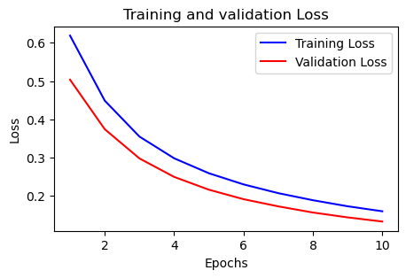

```python
plot(history_dict['loss'], history_dict['val_loss'], "Loss")
```

Plot the training and validation recall

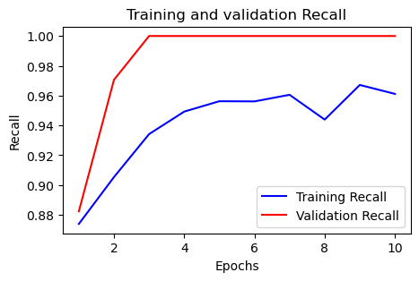

```python
plot(history_dict['recall'], history_dict['val_recall'], "Recall")
```

Evaluate the naive model

```python
results = model.evaluate(X_val, y_val)
print("\nLoss: " + str(int(results[0] * 100)) + "%")
print("Recall: " + str(int(results[1] * 100)) + "%")
```

```
Loss: 13%
Recall: 100%
```

## Scaling up: developing a model that overfits

The ideal model is one that strikes a balance between underfitting and overfitting. To achieve this, we can develop an overfitting model to gain insight into which features and model architectures are causing the overfitting. We can then use this information to adjust the model.

Modifying the model:

- Add layers
- Make the layers bigger
- Train for more epochs

```python
model_of = Sequential()
model_of.add(Dense(64, activation='relu', input_shape=(len(FEATURES),)))
model_of.add(Dense(32, activation='sigmoid'))
model_of.add(Dense(16, activation='sigmoid'))
model_of.add(Dense(8, activation='sigmoid'))
model_of.add(Dense(1, activation='sigmoid'))
model_of.compile(loss='binary_crossentropy', optimizer='adam', metrics=[recall])
```

```python
history_of = model_of.fit(partial_X_train, partial_y_train, validation_data=(X_val, y_val), epochs=200, batch_size=32, verbose=0)
```

Plot the training and validation loss

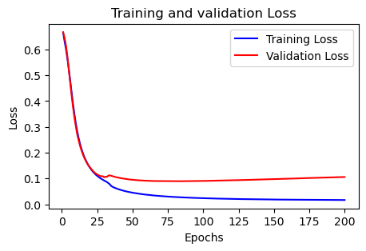

```python
plot(history_of.history['loss'], history_of.history['val_loss'], "Loss")
```

Model overfits: The model's performance starts to deteriorate, as evidenced by an increasing validation loss and a continuously decreasing training loss.

Plot the training and validation recall

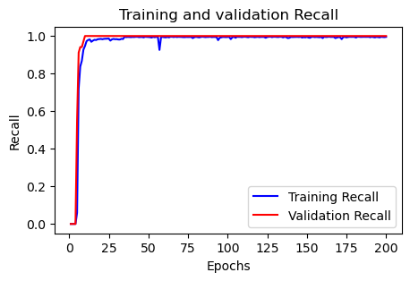

```python
plot(history_of.history['recall'], history_of.history['val_recall'], "Recall")
```

Evaluate the overfit model

```python
results_of = model_of.evaluate(X_val, y_val)
print("\nLoss: " + str(int(results[0] * 100)) + "%")
print("Recall: " + str(int(results[1] * 100)) + "%")
```

```
Loss: 13%
Recall: 100%
```

## Regularizing the model and tuning the hyperparameters

- Add or remove layers
- Add dropout
- Add L1 and/or L2 regularization
- Try different hyperparameters to find the optimal configuration

```python
# Deep Learning With Python by François Chollet - Chapter 3.6.4 Validating your approach using K-fold validation (modified)
def kFV(k, X_train, y_train, _epochs, _model):
    all_histories = []
    all_evaluation_results = []
    VAL_SIZE = len(X_train) // k

    # Prepare validation data from partition k
    for i in range(k):
        print('processing fold #', i)#

        # Prepare training data from other partitions
        X_val = X_train[i * VAL_SIZE: (i + 1) * VAL_SIZE]
        y_val = y_train[i * VAL_SIZE: (i + 1) * VAL_SIZE]
        partial_X_train = np.concatenate([X_train[:i * VAL_SIZE], X_train[(i + 1) * VAL_SIZE:]], axis=0)
        partial_y_train = np.concatenate([y_train[:i * VAL_SIZE], y_train[(i + 1) * VAL_SIZE:]], axis=0)

        # Build Keras model
        model = _model()
        history = model.fit(partial_X_train, partial_y_train, validation_data=(X_val, y_val), epochs=_epochs, batch_size=32, verbose=0)

        # Extract results
        results = model.evaluate(X_val, y_val, verbose=0)
        all_histories.append(history.history)
        all_evaluation_results.append(results)

    # Calculate mean values per epoch
    epochs = len(all_histories[0]['loss'])
    m_loss = [np.mean([x['loss'][i] for x in all_histories]) for i in range(epochs)]
    m_recall = [np.mean([x['recall'][i] for x in all_histories]) for i in range(epochs)]
    m_val_loss = [np.mean([x['val_loss'][i] for x in all_histories]) for i in range(epochs)]
    m_val_recall = [np.mean([x['val_recall'][i] for x in all_histories]) for i in range(epochs)]
    m_eval_loss = np.mean([x[0] for x in all_evaluation_results])
    m_eval_recall = np.mean([x[1] for x in all_evaluation_results])

    return m_loss, m_recall, m_val_loss, m_val_recall, m_eval_loss, m_eval_recall
```

### Iteration 1 - Add or remove layers

```python
# Side by side plots
def plot_2(title1, title2, train1, val1, train2, val2, metric):
    plt.clf()
    fig, (ax1, ax2) = plt.subplots(1, 2, figsize=(10, 3))

    epochs = range(1, len(train1) + 1)
    ax1.plot(epochs, train1, 'b', label='Training ' + metric)
    ax1.plot(epochs, val1, 'r', label='Validation ' + metric)
    ax1.set_title(title1)
    ax1.set_xlabel('Epochs')
    ax1.set_ylabel(metric)
    ax1.legend()

    epochs = range(1, len(train2) + 1)
    ax2.plot(epochs, train2, 'b', label='Training ' + metric)
    ax2.plot(epochs, val2, 'r', label='Validation ' + metric)
    ax2.set_title(title2)
    ax2.set_xlabel('Epochs')
    ax2.set_ylabel(metric)
    ax2.legend()

    plt.show()
```

Model 1 has the same number of epochs as the overfitting model, with 1 reduced layer.

```
processing fold # 0
processing fold # 1
processing fold # 2
processing fold # 3
```

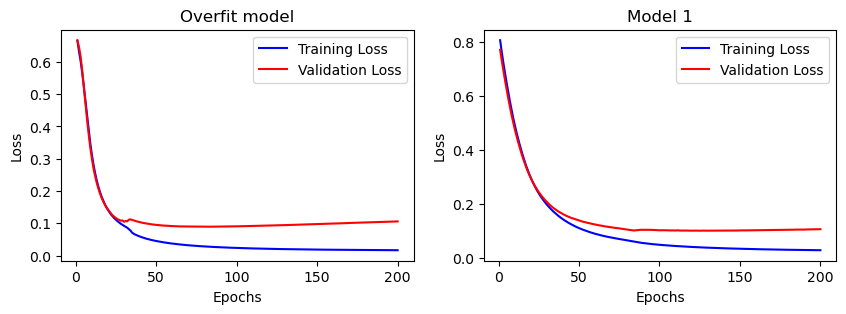

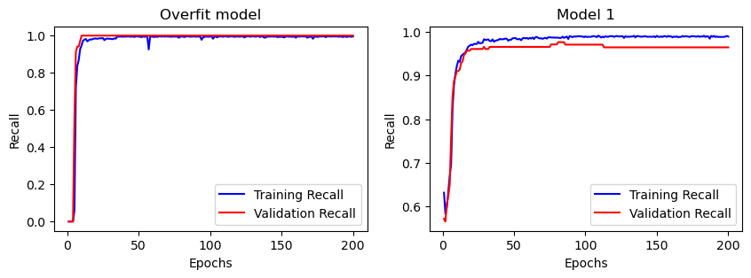

```
Loss: 10%
Recall: 96%
```

```python
def model_1():
    tf.random.set_seed(42)
    model = Sequential()
    model.add(Dense(32, activation = 'relu', input_shape = (len(FEATURES),)))
    model.add(Dense(16, activation = 'sigmoid'))
    model.add(Dense(8, activation = 'sigmoid'))
    model.add(Dense(1, activation = 'sigmoid'))
    model.compile(optimizer = 'adam', loss = 'binary_crossentropy', metrics = [recall])
    return model

m_loss_1, m_recall_1, m_val_loss_1, m_val_recall_1, m_eval_loss_1, m_eval_recall_1 = kFV(4, X_train, y_train, _epochs = 200, _model = model_1)
plot_2("Overfit model", "Model 1", history_of.history['loss'], history_of.history['val_loss'], m_loss_1, m_val_loss_1, "Loss")
plot_2("Overfit model", "Model 1", history_of.history['recall'], history_of.history['val_recall'], m_recall_1, m_val_recall_1, "Recall")

print("\nLoss: " + str(int(m_eval_loss_1 * 100)) + "%")
print("Recall: " + str(int(m_eval_recall_1 * 100)) + "%")
```

Model 2 has the same number of epochs as the overfitting model, with 2 reduced layers.

```
processing fold # 0
processing fold # 1
processing fold # 2
processing fold # 3
```

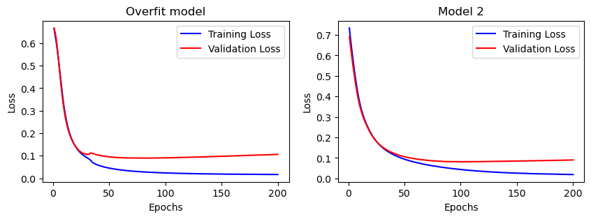

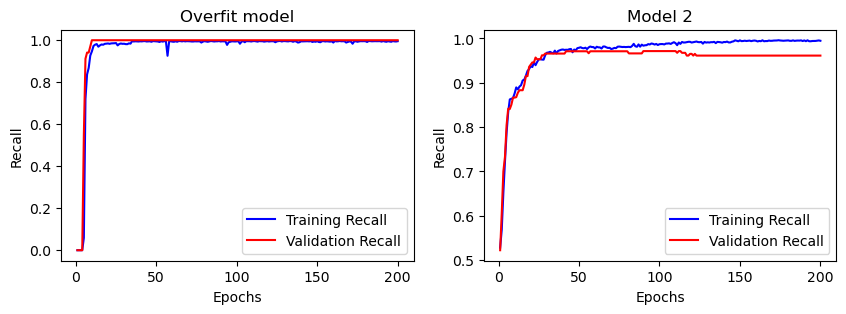

```
Loss: 9%
Recall: 96%
```

```python
def model_2():
    tf.random.set_seed(42)
    model = Sequential()
    model.add(Dense(16, activation = 'relu', input_shape = (len(FEATURES),)))
    model.add(Dense(8, activation = 'sigmoid'))
    model.add(Dense(1, activation = 'sigmoid'))
    model.compile(optimizer = 'adam', loss = 'binary_crossentropy', metrics = [recall])
    return model

m_loss_2, m_recall_2, m_val_loss_2, m_val_recall_2, m_eval_loss_2, m_eval_recall_2 = kFV(4, X_train, y_train, _epochs = 200, _model = model_2)
plot_2("Overfit model", "Model 2", history_of.history['loss'], history_of.history['val_loss'], m_loss_2, m_val_loss_2, "Loss")
plot_2("Overfit model", "Model 2", history_of.history['recall'], history_of.history['val_recall'], m_recall_2, m_val_recall_2, "Recall")

print("\nLoss: " + str(int(m_eval_loss_2 * 100)) + "%")
print("Recall: " + str(int(m_eval_recall_2 * 100)) + "%")
```

Model 2 seems to perform better. We can see an improvement in model 2 with a less aggressive overfit. However, as it is still overfitting, we will have to continue tuning the hyperparameters.

### Iteration 2 - Increase or decrease epochs

Decreasing the number of epochs will lower the degree of overfitting.

```
processing fold # 0
processing fold # 1
processing fold # 2
processing fold # 3
```

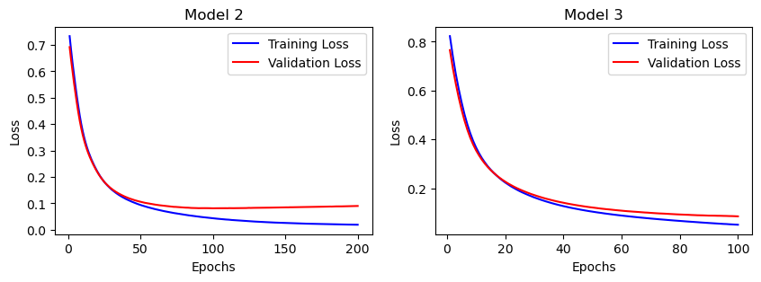

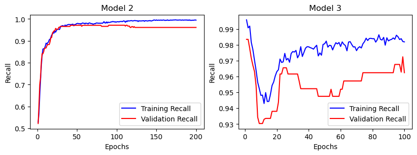

```
Loss: 8%
Recall: 96%
```

```python
def model_3():
    tf.random.set_seed(42)
    model = Sequential()
    model.add(Dense(16, activation='relu', input_shape=(len(FEATURES),)))
    model.add(Dense(8, activation = 'sigmoid'))
    model.add(Dense(1, activation='sigmoid'))
    model.compile(optimizer='adam', loss='binary_crossentropy', metrics=[recall])
    return model

m_loss_3, m_recall_3, m_val_loss_3, m_val_recall_3, m_eval_loss_3, m_eval_recall_3 = kFV(4, X_train, y_train, _epochs=100, _model=model_3)
plot_2("Model 2", "Model 3", m_loss_2, m_val_loss_2, m_loss_3, m_val_loss_3, "Loss")
plot_2("Model 2", "Model 3", m_recall_2, m_val_recall_2, m_recall_3, m_val_recall_3, "Recall")

print("\nLoss: " + str(int(m_eval_loss_3 * 100)) + "%")
print("Recall: " + str(int(m_eval_recall_3 * 100)) + "%")
```

```
processing fold # 0
processing fold # 1
processing fold # 2
processing fold # 3
```

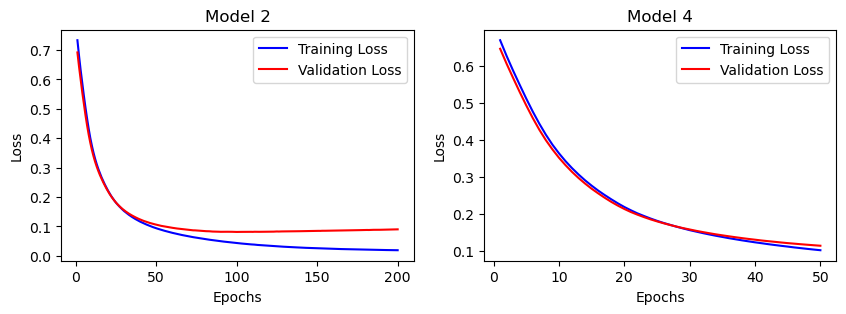

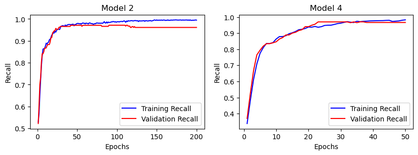

```
Loss: 11%
Recall: 96%
```

```python
def model_4():
    tf.random.set_seed(42)
    model = Sequential()
    model.add(Dense(16, activation='relu', input_shape=(len(FEATURES),)))
    model.add(Dense(8, activation = 'sigmoid'))
    model.add(Dense(1, activation='sigmoid'))
    model.compile(optimizer='adam', loss='binary_crossentropy', metrics=[recall])
    return model

m_loss_4, m_recall_4, m_val_loss_4, m_val_recall_4, m_eval_loss_4, m_eval_recall_4 = kFV(4, X_train, y_train, _epochs=50, _model=model_4)
plot_2("Model 2", "Model 4", m_loss_2, m_val_loss_2, m_loss_4, m_val_loss_4, "Loss")
plot_2("Model 2", "Model 4", m_recall_2, m_val_recall_2, m_recall_4, m_val_recall_4, "Recall")

print("\nLoss: " + str(int(m_eval_loss_4 * 100)) + "%")
print("Recall: " + str(int(m_eval_recall_4 * 100)) + "%")
```

We seem to have generated a good fit with model 4. However, there are still ways to improve the model using regularization techniques which I will experiment with below.

### Iteration 3 - Add dropout

Adding dropout can help the neural network learn more robust features, as it cannot rely on any single neuron to always be present.

```
processing fold # 0
processing fold # 1
processing fold # 2
processing fold # 3
```

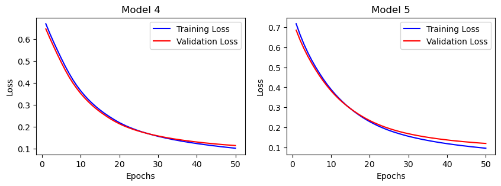

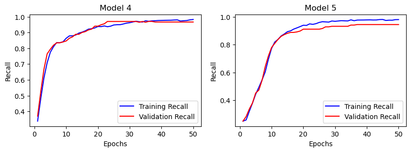

```
Loss: 12%
Recall: 94%
```

```python
def model_5():
    tf.random.set_seed(42)
    model = Sequential()
    model.add(Dense(16, activation='relu', input_shape=(len(FEATURES),)))
    tf.keras.layers.Dropout(0.2)
    model.add(Dense(8, activation='sigmoid'))
    tf.keras.layers.Dropout(0.2)
    model.add(Dense(1, activation='sigmoid'))
    model.compile(optimizer='adam', loss='binary_crossentropy', metrics=[recall])
    return model

m_loss_5, m_recall_5, m_val_loss_5, m_val_recall_5, m_eval_loss_5, m_eval_recall_5 = kFV(4, X_train, y_train, _epochs=50, _model=model_5)
plot_2("Model 4", "Model 5", m_loss_4, m_val_loss_4, m_loss_5, m_val_loss_5, "Loss")
plot_2("Model 4", "Model 5", m_recall_4, m_val_recall_4, m_recall_5, m_val_recall_5, "Recall")

print("\nLoss: " + str(int(m_eval_loss_5 * 100)) + "%")
print("Recall: " + str(int(m_eval_recall_5 * 100)) + "%")
```

### Iteration 4 - Add L1 and L2 regularization

```
processing fold # 0
processing fold # 1
processing fold # 2
processing fold # 3
```

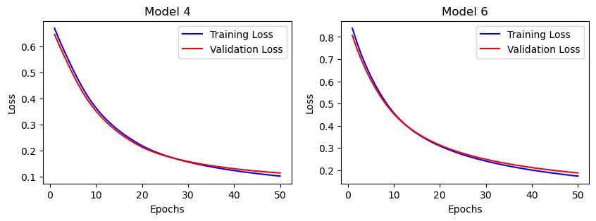

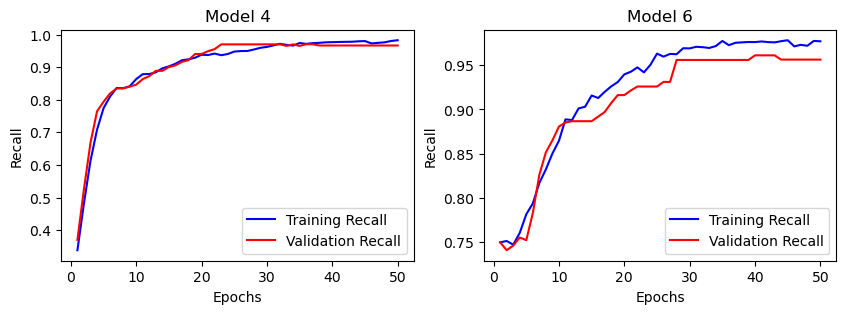

```
Loss: 18%
Recall: 95%
```

```python
def model_6():
    tf.random.set_seed(42)
    model = Sequential()
    model.add(Dense(16, activation='relu', kernel_regularizer=tf.keras.regularizers.l1(0.001), input_shape=(len(FEATURES),)))
    model.add(Dense(8, activation='sigmoid', kernel_regularizer=tf.keras.regularizers.l2(0.001)))
    model.add(Dense(1, activation='sigmoid'))
    model.compile(optimizer='adam', loss='binary_crossentropy', metrics=[recall])
    return model

m_loss_6, m_recall_6, m_val_loss_6, m_val_recall_6, m_eval_loss_6, m_eval_recall_6 = kFV(4, X_train, y_train, _epochs=50, _model=model_6)
plot_2("Model 4", "Model 6", m_loss_4, m_val_loss_4, m_loss_6, m_val_loss_6, "Loss")
plot_2("Model 4", "Model 6", m_recall_4, m_val_recall_4, m_recall_6, m_val_recall_6, "Recall")

print("\nLoss: " + str(int(m_eval_loss_6 * 100)) + "%")
print("Recall: " + str(int(m_eval_recall_6 * 100)) + "%")
```

The model's performance is reduced with too many layers of regularization. We will create model 7 with only L2 regularization.

```
processing fold # 0
processing fold # 1
processing fold # 2
processing fold # 3
```

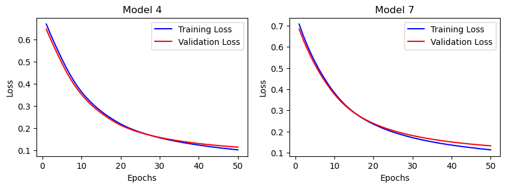

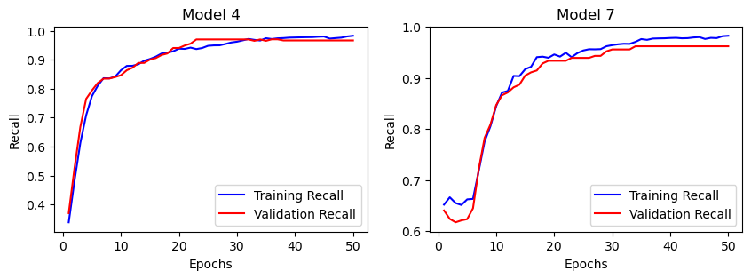

```
Loss: 13%
Recall: 96%
```

```python
def model_7():
    tf.random.set_seed(42)
    model = Sequential()
    model.add(Dense(16, activation='relu', input_shape=(len(FEATURES),)))
    model.add(Dense(8, activation='sigmoid', kernel_regularizer=tf.keras.regularizers.l2(0.001)))
    model.add(Dense(1, activation='sigmoid'))
    model.compile(optimizer='adam', loss='binary_crossentropy', metrics=[recall])
    return model

m_loss_7, m_recall_7, m_val_loss_7, m_val_recall_7, m_eval_loss_7, m_eval_recall_7 = kFV(4, X_train, y_train, _epochs=50, _model=model_7)
plot_2("Model 4", "Model 7", m_loss_4, m_val_loss_4, m_loss_7, m_val_loss_7, "Loss")
plot_2("Model 4", "Model 7", m_recall_4, m_val_recall_4, m_recall_7, m_val_recall_7, "Recall")

print("\nLoss: " + str(int(m_eval_loss_7 * 100)) + "%")
print("Recall: " + str(int(m_eval_recall_7 * 100)) + "%")
```

Model 7 achieves a good fit, similar to model 4. Final evaluation of results using test data will show if the model is well-behaved.

# Results

## Presentation of results

Evaluation of results on validation data

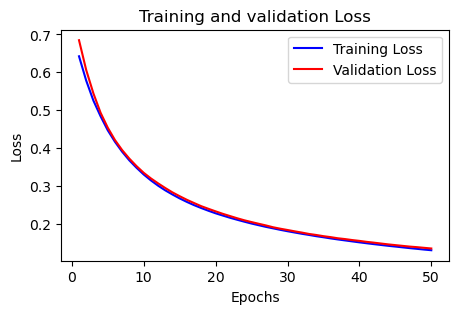

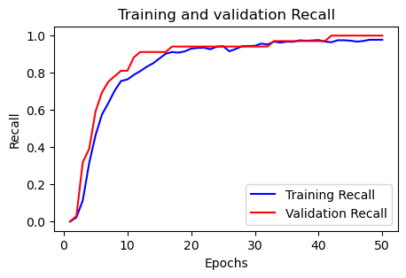

```
Loss: 13%
Recall: 100%
```

```python
model = model_7()
history = model.fit(partial_X_train, partial_y_train, validation_data=(X_val, y_val), epochs=50, batch_size=32, verbose=0)
results = model.evaluate(X_val, y_val)

plot(history.history['loss'], history.history['val_loss'], "Loss")
plot(history.history['recall'], history.history['val_recall'], "Recall")

print("\nLoss: " + str(int(results[0] * 100)) + "%")
print("Recall: " + str(int(results[1] * 100)) + "%")
```

Evaluation of results on test data

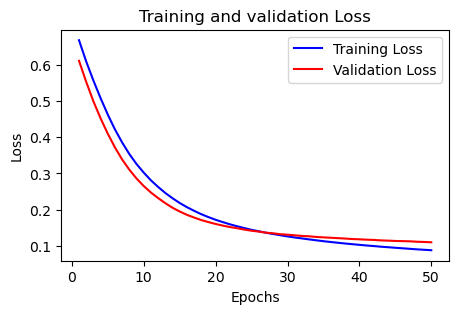

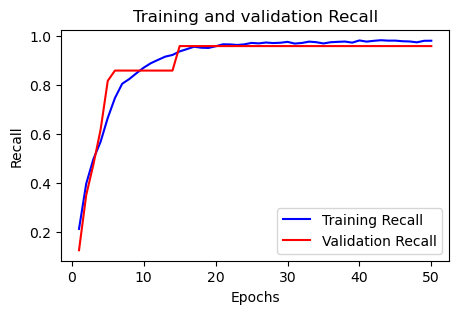

```
Loss: 10%
Recall: 95%
```

```python
model = model_7()
history = model.fit(X_train, y_train, validation_data=(X_test, y_test), epochs=50, batch_size=32, verbose=0)
results = model.evaluate(X_test, y_test)

plot(history.history['loss'], history.history['val_loss'], "Loss")
plot(history.history['recall'], history.history['val_recall'], "Recall")

print("\nLoss: " + str(int(results[0] * 100)) + "%")
print("Recall: " + str(int(results[1] * 100)) + "%")
```

# References

[Chollet, F. (2018). Deep Learning With Python: Chapter 1-4.](https://www.manning.com/books/deep-learning-with-python)  
[GeeksforGeeks. (2021, January 13). ML | Implementing L1 and L2 regularization using Sklearn.](https://www.geeksforgeeks.org/ml-implementing-l1-and-l2-regularization-using-sklearn/)  
[Tutorialspoint. (2021). How to make two plots side by side using Python.](https://www.tutorialspoint.com/how-to-make-two-plots-side-by-side-using-python)